# Aula 1

Lucas Delmondes

21 agosto, 2023

Puxando as bibliotecas necessarias:

```r
library(readxl)
library(ggplot2)
library(wooldridge)
```

# 1 EXEMPLO 1

Lendo nossa base de dados em Excel

```r
database<-read_excel("book1.xlsx")
database
```

```
## # A tibble: 12 × 3
##    PERÍODO     Y     X
##      <dbl> <dbl> <dbl>
##  1    1980 2447. 3776.
##  2    1981 2477. 3843.
##  3    1982 2504. 3760.
##  4    1983 2619. 3907.
##  5    1984 2746. 4148.
##  6    1985 2866. 4280.
##  7    1986 2969. 4404.
##  8    1987 3052. 4540.
##  9    1988 3162. 4719.
## 10    1989 3223. 4838
## 11    1990 3260. 4878.
## 12    1991 3241. 4821
```

Puxando o plot dos elementos de nossas planilha

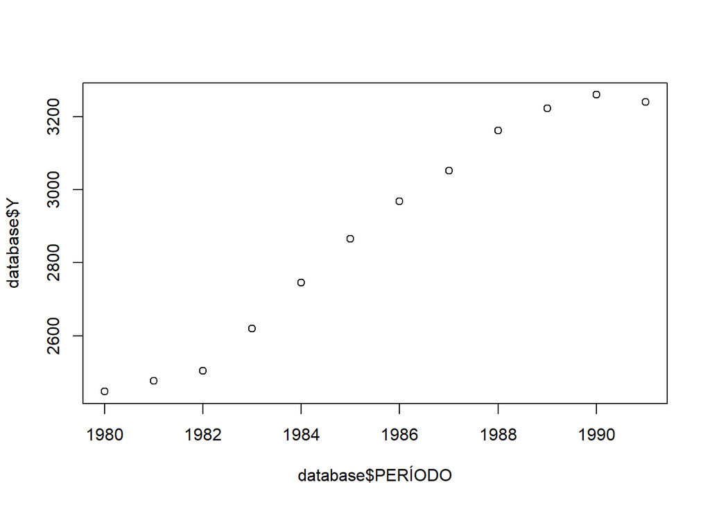

```r
p1<-plot(database$PERÍODO, database$Y)
```

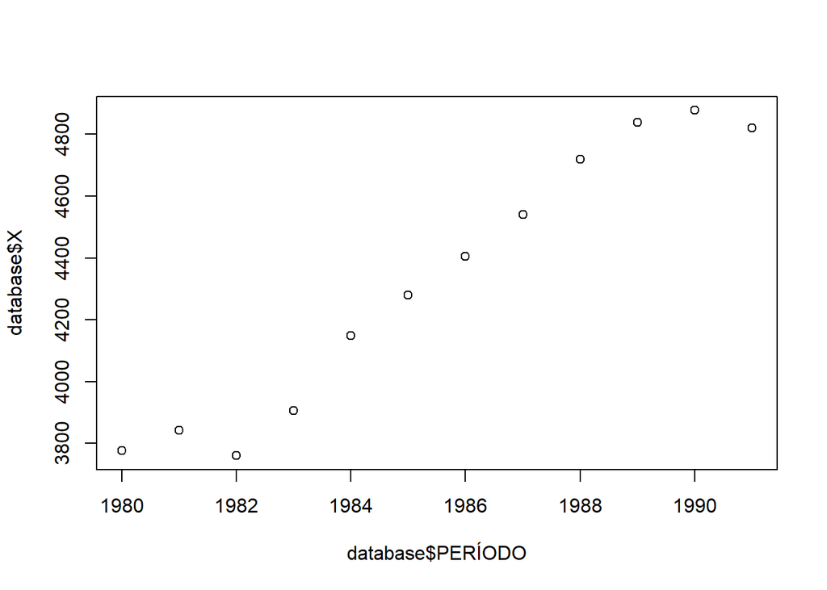

```r
p2<-plot(database$PERÍODO, database$X)
```

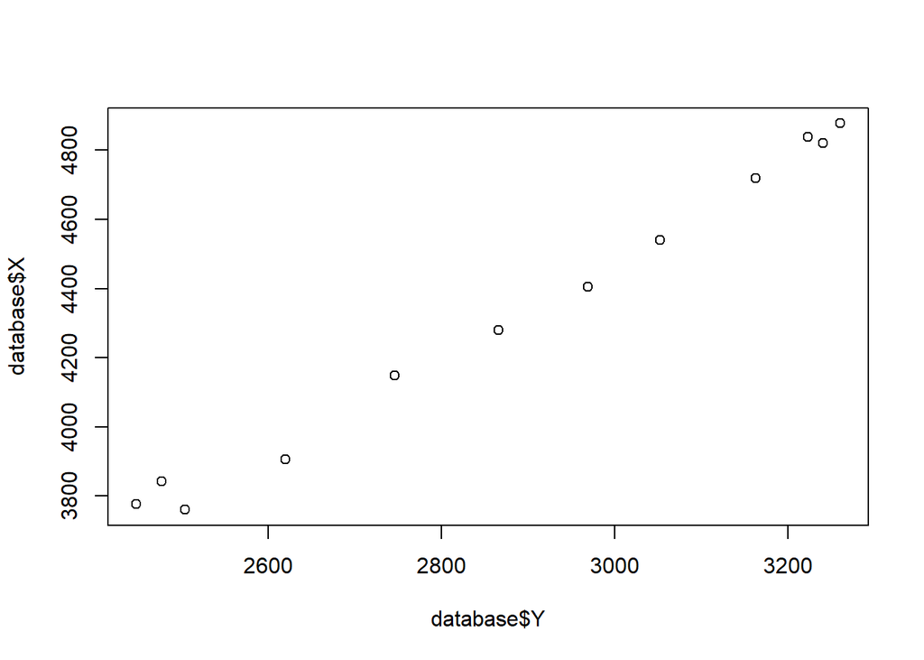

```r
p3<-plot(database$Y, database$X)
```

Agora fazendo a regressão linear:

```r
reg<-lm(Y ~ X, database)
summary(reg)
```

```
##
## Call:
## lm(formula = Y ~ X, data = database)
##
## Residuals:
##     Min      1Q  Median      3Q     Max
## -56.160 -19.012   1.841  21.475  40.656
##
## Coefficients:
##               Estimate Std. Error t value Pr(>|t|)
## (Intercept) -231.79510   94.52751  -2.452   0.0341 *
## X              0.71943    0.02175  33.078 1.51e-11 ***
## ---
## Signif. codes:  0 '***' 0.001 '**' 0.01 '*' 0.05 '.' 0.1 ' ' 1
##
## Residual standard error: 31.38 on 10 degrees of freedom
## Multiple R-squared:  0.9909, Adjusted R-squared:   0.99
## F-statistic:  1094 on 1 and 10 DF,  p-value: 1.505e-11
```

Mais alguns plots:

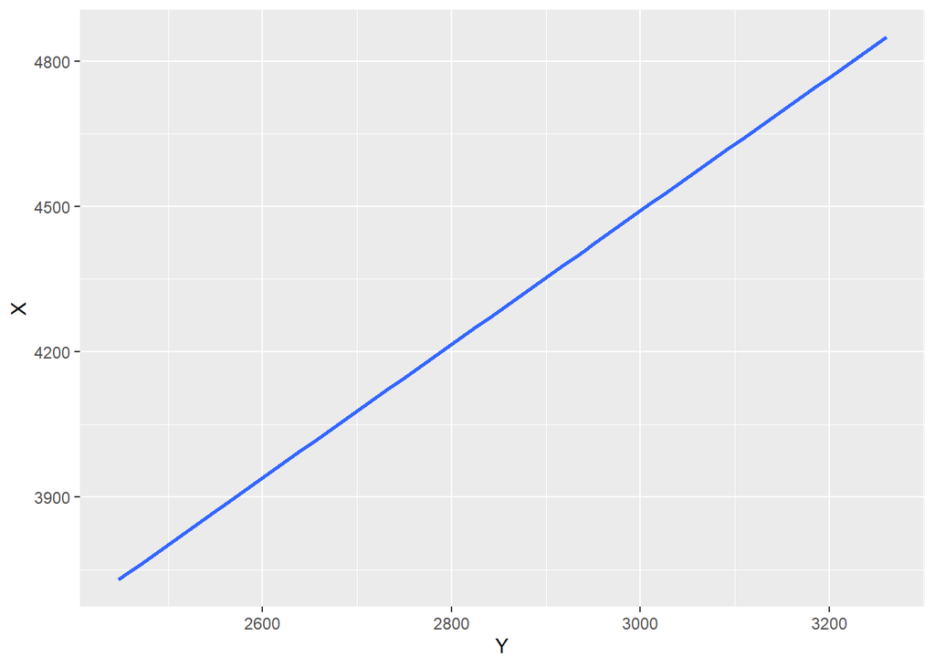

```r
ggplot(database, aes(x=Y, y=X))+
  geom_smooth(method = lm, se = FALSE)
```

# 2 EXEMPLO 2

```r
data("wage1")
```

Fazendo a regressão com o log do wage para no final virar uma relação entre: um aumento de ano de estudo é igual a uma variação em porcentagem no salário

```r
reg2 <- lm(lwage ~ educ, wage1)
summary(reg2)
```

```
##
## Call:
## lm(formula = lwage ~ educ, data = wage1)
##
## Residuals:
##      Min       1Q   Median       3Q      Max
## -2.21158 -0.36393 -0.07263  0.29712  1.52339
##
## Coefficients:
##             Estimate Std. Error t value Pr(>|t|)
## (Intercept) 0.583773   0.097336   5.998 3.74e-09 ***
## educ        0.082744   0.007567  10.935  < 2e-16 ***
## ---
## Signif. codes:  0 '***' 0.001 '**' 0.01 '*' 0.05 '.' 0.1 ' ' 1
##
## Residual standard error: 0.4801 on 524 degrees of freedom
## Multiple R-squared:  0.1858, Adjusted R-squared:  0.1843
## F-statistic: 119.6 on 1 and 524 DF,  p-value: < 2.2e-16
```

Agora os plots:

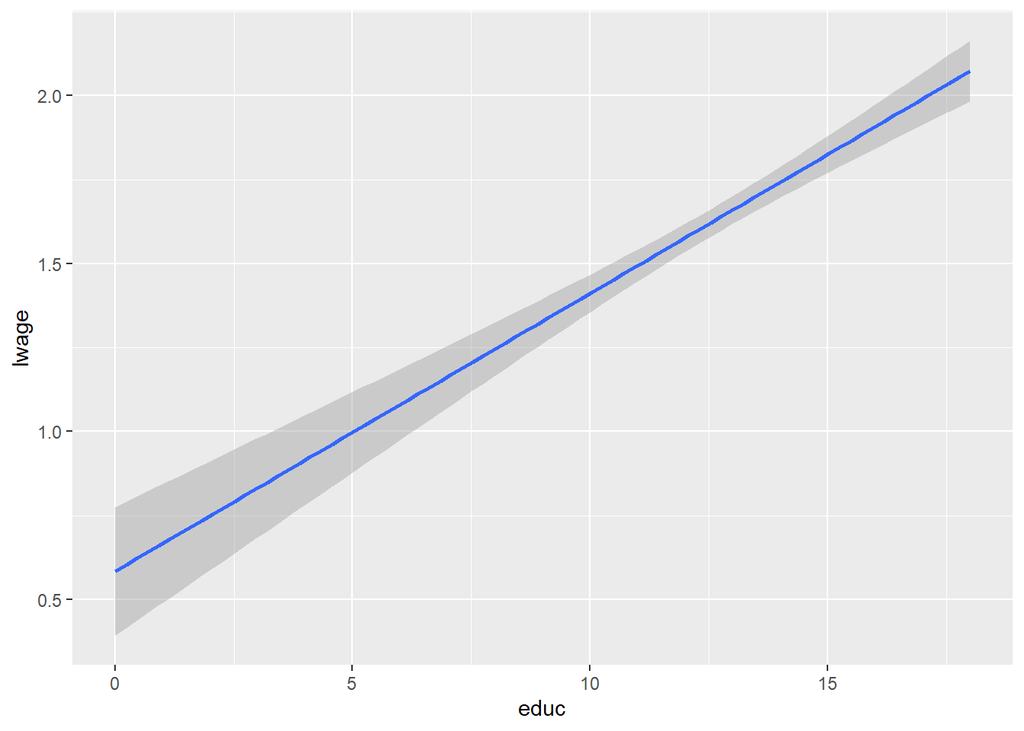

```r
ggplot(wage1, aes(x=educ, y=lwage))+
  geom_smooth(method = lm)
```

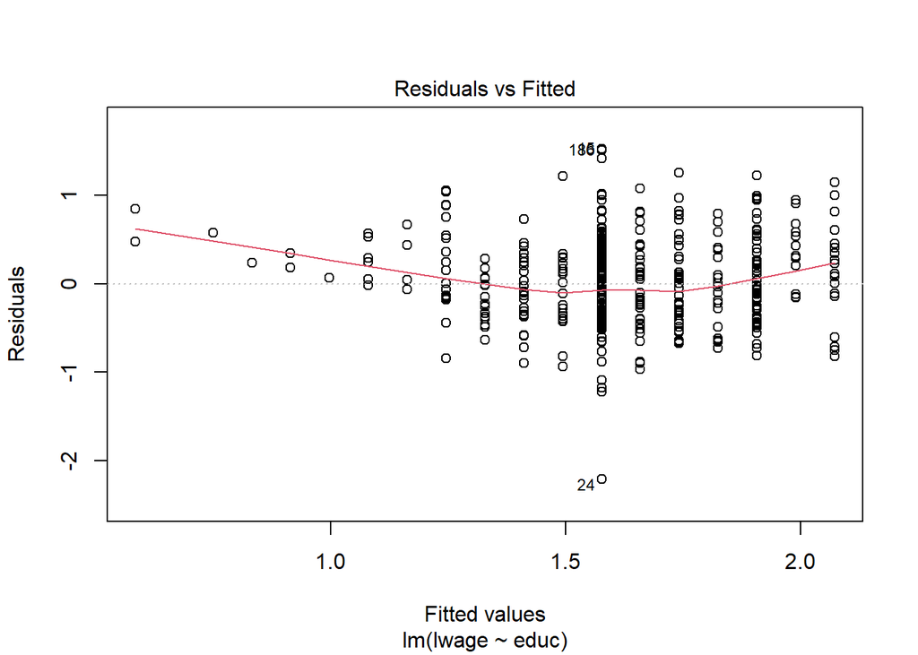

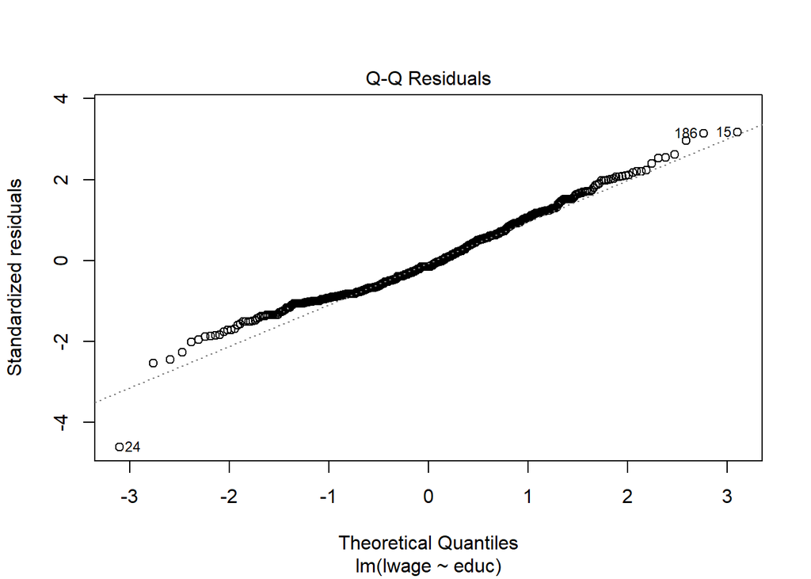

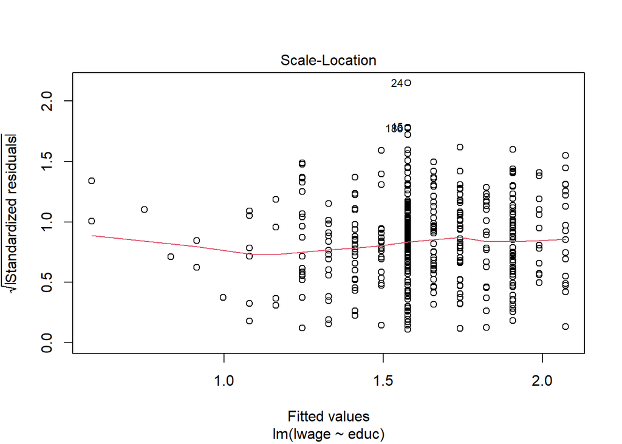

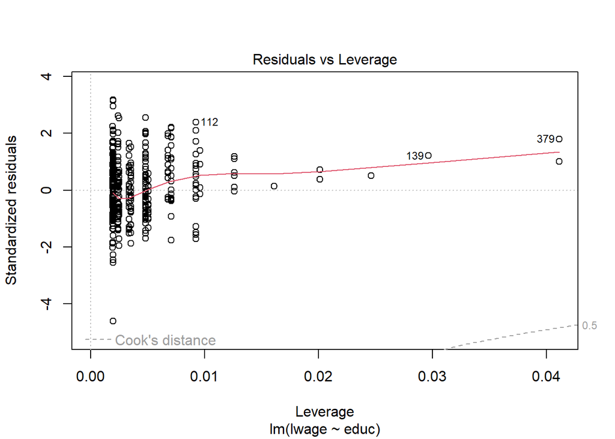

```r
plot(reg2)
```

## 2.1 Criando a variavel

Criando uma variavel, que seria o log da educação e adicionando ela ao meu dataset

```r
#criando uma constante para não termos problemas ao realizar o cálculo do log
constante <- 0.001
leduc <- log(wage1$educ + constante)

#adicionando nossa variavel ao database
wage1$leduc <- leduc
```

Fazendo a regressão com o log da renda para o log da educação, temos que:

```r
reg3 <- lm(lwage ~ leduc, wage1)
summary(reg3)
```

```
##
## Call:
## lm(formula = lwage ~ leduc, data = wage1)
##
## Residuals:
##      Min       1Q   Median       3Q      Max
## -2.26025 -0.41270 -0.08112  0.30325  1.52716
##
## Coefficients:
##             Estimate Std. Error t value Pr(>|t|)
## (Intercept)  1.22359    0.09216  13.277  < 2e-16 ***
## leduc        0.16168    0.03613   4.476 9.36e-06 ***
## ---
## Signif. codes:  0 '***' 0.001 '**' 0.01 '*' 0.05 '.' 0.1 ' ' 1
##
## Residual standard error: 0.5222 on 524 degrees of freedom
## Multiple R-squared:  0.03682,    Adjusted R-squared:  0.03498
## F-statistic: 20.03 on 1 and 524 DF,  p-value: 9.358e-06
```

Temos que o aumento de 1% em educação impacta em um aumento de 0,16% no salário

Agora os plots:

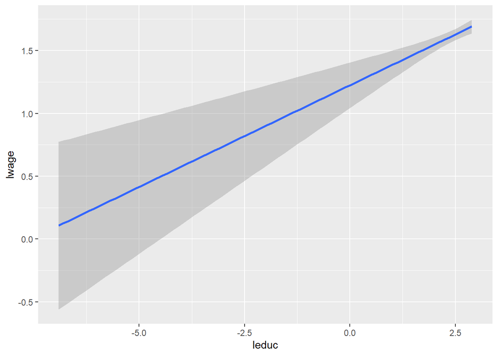

```r
ggplot(wage1, aes(x=leduc, y=lwage))+
  geom_smooth(method = lm)
```

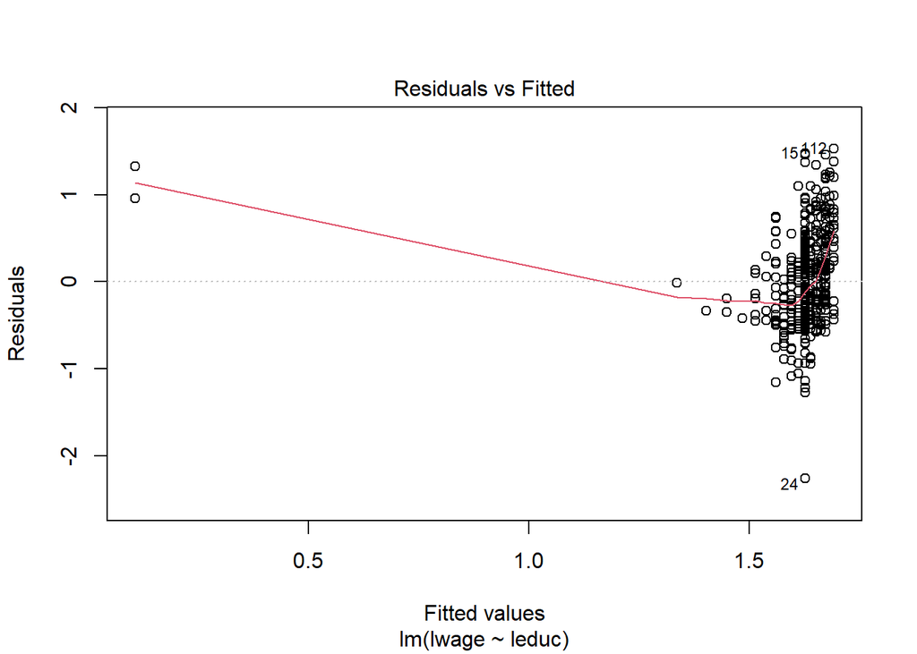

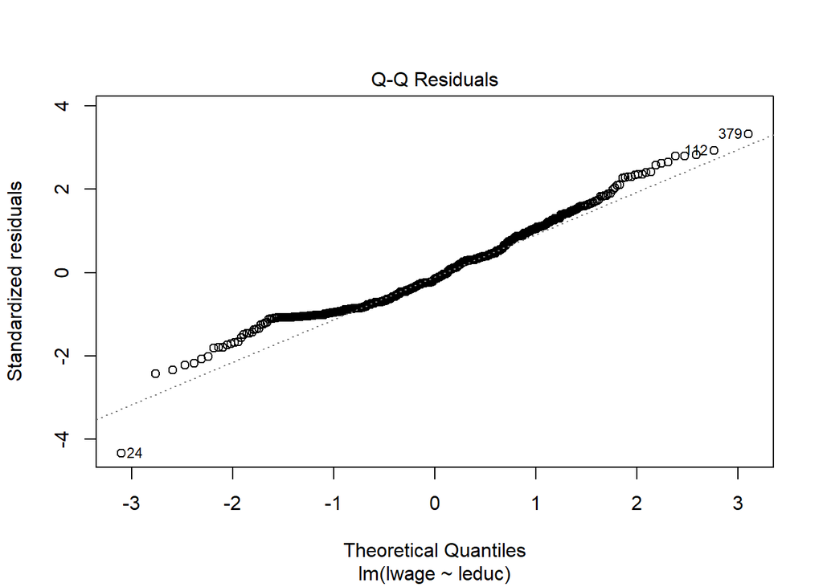

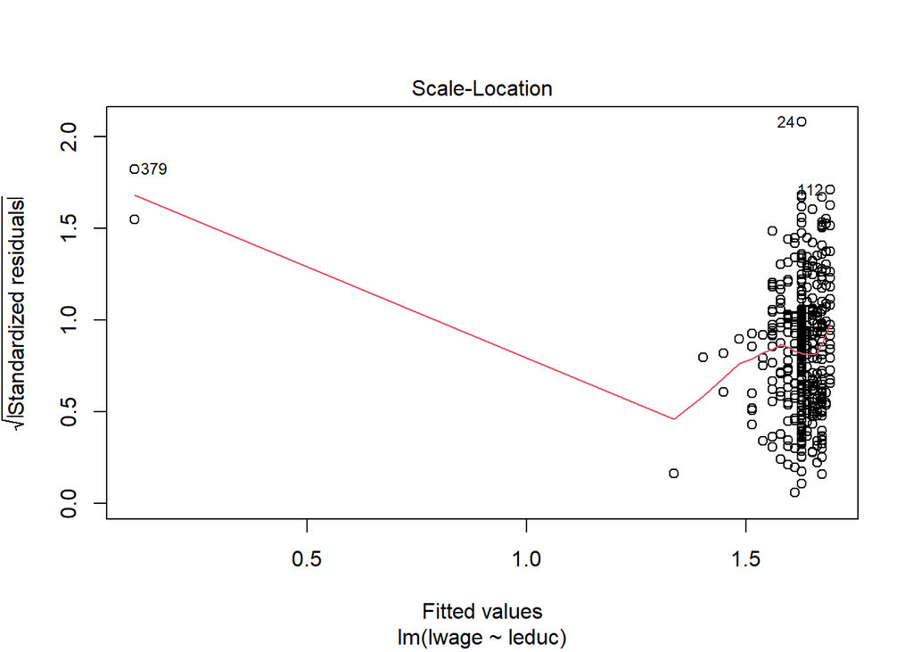

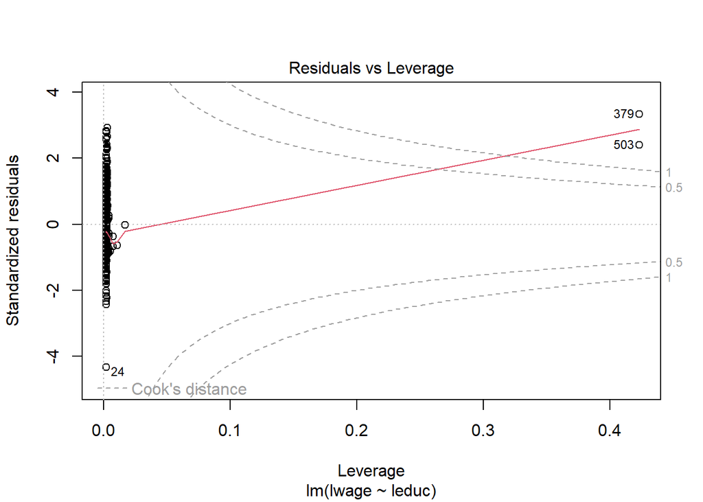

```r
plot(reg3)
```

# 3 Procurando o melhor modelo

No meu modelo irei utilizar as variaveis de anos de educação, anos de experiencia, o fato da pessoa ser mulher e o fato da pessoa ser casada para explicar a composição do salário por hora de um trabalhador.

```r
reghello <- lm(wage ~ educ + exper + female + married, wage1)
summary(reghello)
```

```
##
## Call:
## lm(formula = wage ~ educ + exper + female + married, data = wage1)
##
## Residuals:
##     Min      1Q  Median      3Q     Max
## -6.4057 -1.9042 -0.5982  1.1454 14.6545
##
## Coefficients:
##             Estimate Std. Error t value Pr(>|t|)
## (Intercept) -1.79066    0.75121  -2.384   0.0175 *
## educ         0.58332    0.05166  11.292  < 2e-16 ***
## exper        0.05567    0.01106   5.035 6.59e-07 ***
## female      -2.06710    0.27221  -7.594 1.45e-13 ***
## married      0.66024    0.29685   2.224   0.0266 *
## ---
## Signif. codes:  0 '***' 0.001 '**' 0.01 '*' 0.05 '.' 0.1 ' ' 1
##
## Residual standard error: 3.066 on 521 degrees of freedom
## Multiple R-squared:  0.3158, Adjusted R-squared:  0.3105
## F-statistic: 60.12 on 4 and 521 DF,  p-value: < 2.2e-16
```

```r
#se colocarmos "0" antes das variaveis explicativas, o intercepto é retirado
reghello_ <- lm(wage ~ 0 + educ + exper + female + married , wage1)
summary(reghello_)
```

```
##
## Call:
## lm(formula = wage ~ 0 + educ + exper + female + married, data = wage1)
##
## Residuals:
##     Min      1Q  Median      3Q     Max
## -6.0751 -1.9233 -0.6914  0.9769 15.0723
##
## Coefficients:
##          Estimate Std. Error t value Pr(>|t|)
## educ     0.469830   0.020125  23.345  < 2e-16 ***
## exper    0.043475   0.009845   4.416 1.22e-05 ***
## female  -2.247075   0.262697  -8.554  < 2e-16 ***
## married  0.636449   0.298011   2.136   0.0332 *
## ---
## Signif. codes:  0 '***' 0.001 '**' 0.01 '*' 0.05 '.' 0.1 ' ' 1
##
## Residual standard error: 3.08 on 522 degrees of freedom
## Multiple R-squared:  0.8054, Adjusted R-squared:  0.8039
## F-statistic:   540 on 4 and 522 DF,  p-value: < 2.2e-16
```

```r
# Salvando nosso R quadrado
reghello_s = summary(reghello_)
r1 <- reghello_s$adj.r.squared
r1
```

```
## [1] 0.8038796
```

Ok, agora quero substituir a experiencia pelo tempo de empresa de um profissional.

No meu modelo irei utilizar as variaveis de anos de educação, anos de mesma empresa, o fato da pessoa ser mulher e o fato da pessoa ser casada para explicar a composição do salário por hora de um trabalhador.

```r
regtest <- lm(wage ~ educ + tenure + female + married, wage1)
summary(regtest)
```

```
##
## Call:
## lm(formula = wage ~ educ + tenure + female + married, data = wage1)
##
## Residuals:
##     Min      1Q  Median      3Q     Max
## -7.5538 -1.7647 -0.5327  1.0318 13.9883
##
## Coefficients:
##             Estimate Std. Error t value Pr(>|t|)
## (Intercept) -1.13853    0.65517  -1.738   0.0828 .
## educ         0.52936    0.04698  11.268  < 2e-16 ***
## tenure       0.15418    0.01871   8.241 1.40e-15 ***
## female      -1.71050    0.26611  -6.428 2.93e-10 ***
## married      0.68522    0.27466   2.495   0.0129 *
## ---
## Signif. codes:  0 '***' 0.001 '**' 0.01 '*' 0.05 '.' 0.1 ' ' 1
##
## Residual standard error: 2.954 on 521 degrees of freedom
## Multiple R-squared:  0.3652, Adjusted R-squared:  0.3604
## F-statistic: 74.95 on 4 and 521 DF,  p-value: < 2.2e-16
```

```r
regpft <- lm(wage ~ 0 + educ + tenure + female + married, wage1)
summary(regpft)
```

```
##
## Call:
## lm(formula = wage ~ 0 + educ + tenure + female + married, data = wage1)
##
## Residuals:
##     Min      1Q  Median      3Q     Max
## -7.4119 -1.8120 -0.5906  0.9615 14.1244
##
## Coefficients:
##         Estimate Std. Error t value Pr(>|t|)
## educ     0.45488    0.01928  23.594  < 2e-16 ***
## tenure   0.14757    0.01835   8.040 6.06e-15 ***
## female  -1.86283    0.25175  -7.400 5.49e-13 ***
## married  0.59951    0.27072   2.215   0.0272 *
## ---
## Signif. codes:  0 '***' 0.001 '**' 0.01 '*' 0.05 '.' 0.1 ' ' 1
##
## Residual standard error: 2.959 on 522 degrees of freedom
## Multiple R-squared:  0.8203, Adjusted R-squared:  0.819
## F-statistic: 595.9 on 4 and 522 DF,  p-value: < 2.2e-16
```

```r
# Salvando nosso R quadrado
regpft_s = summary(regpft)
r2 <- regpft_s$adj.r.squared
r2
```

```
## [1] 0.8189704
```

Agora vamos comparar os R quadrados dos dois modelos e ver o que temos:

```r
if (r1 > r2) {
  print ("Com experincia é melhor")
} else {
  print ("Com anos de empresa é melhor")
}
```

```
## [1] "Com anos de empresa é melhor"
```

Interpretando temos que: O aumento de 1 ano de educação resulta em um aumento de $0,45 em salário. O aumento de 1 ano de mesma empresa resulta em um aumento de $0,14 em salário. O fato da pessoa ser mulher apresenta-se como uma diminuição de $1,86 em salário. O fato da pessoa ser casada apresenta-se com um aumento de $0,59 em salário.

Agora vamos fazer os plots dessa regressão escolhida:

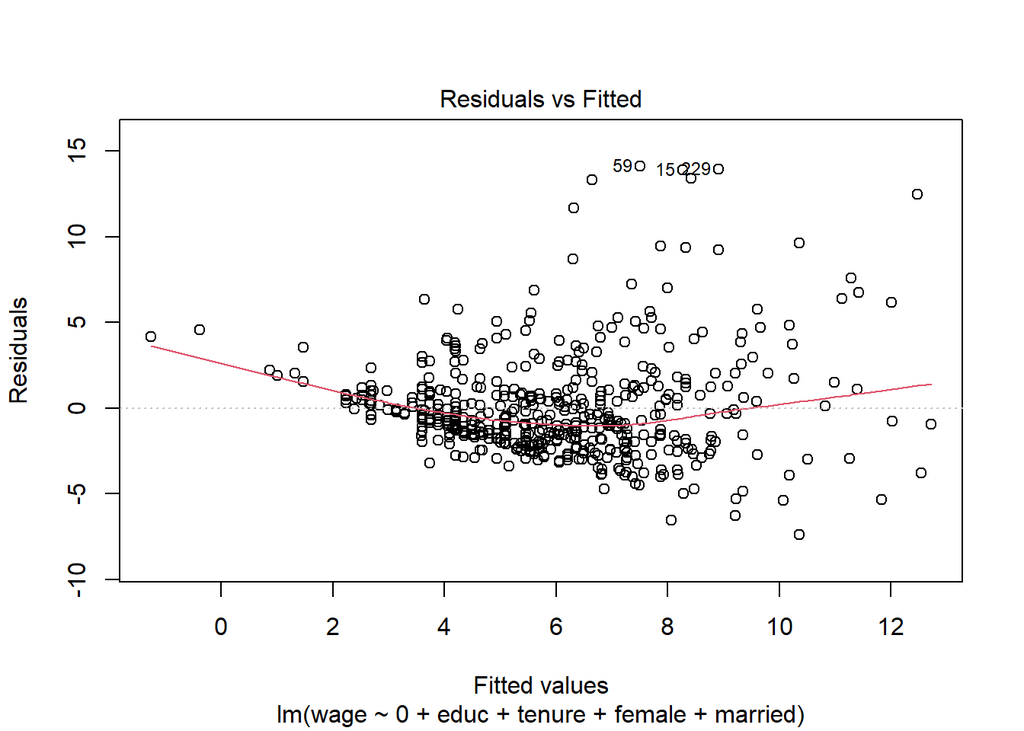

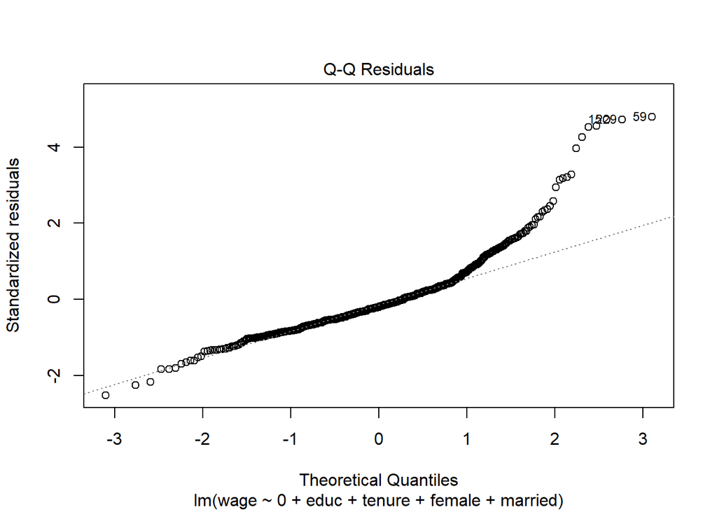

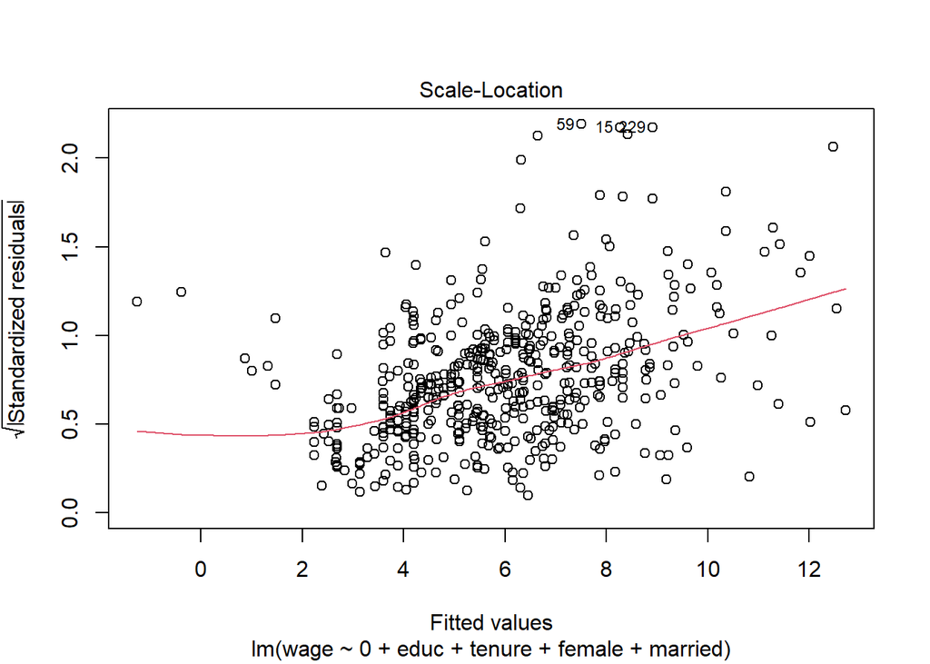

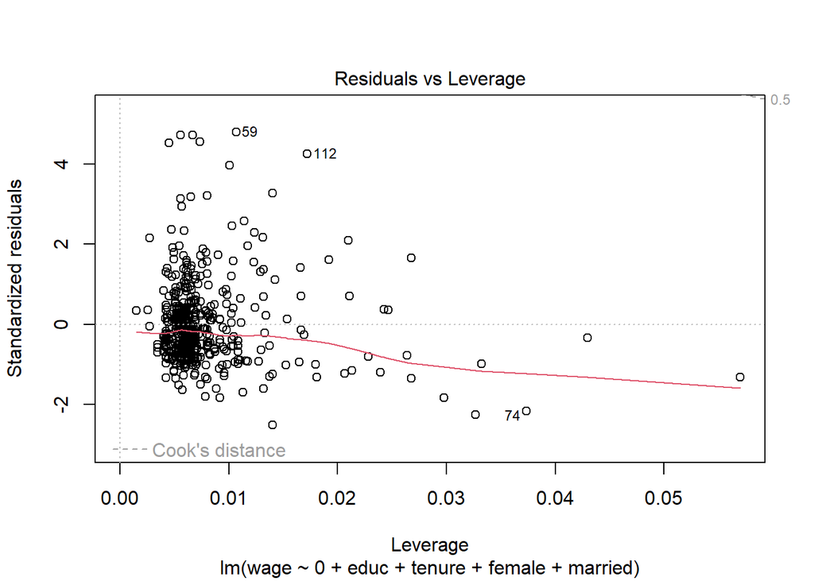

```r
plot(regpft)
```

Quis manter a mesma regressão usada acima, mas agora adicionando a diferenciação da área em que o profissional atua:

```r
regexp <- lm(wage ~ 0 + educ + tenure + female + married + construc + ndurman + trcommpu + trade + services + profserv + profocc + clerocc + servocc, wage1)
summary(regexp)
```

```
##
## Call:
## lm(formula = wage ~ 0 + educ + tenure + female + married + construc +
##     ndurman + trcommpu + trade + services + profserv + profocc +
##     clerocc + servocc, data = wage1)
##
## Residuals:
##    Min     1Q Median     3Q    Max
## -8.203 -1.516 -0.323  1.062 13.563
##
## Coefficients:
##          Estimate Std. Error t value Pr(>|t|)
## educ      0.46727    0.02944  15.870  < 2e-16 ***
## tenure    0.13918    0.01760   7.909 1.60e-14 ***
## female   -1.34156    0.27298  -4.915 1.20e-06 ***
## married   0.61001    0.25867   2.358  0.01874 *
## construc -0.40431    0.63573  -0.636  0.52507
## ndurman  -0.97284    0.47029  -2.069  0.03908 *
## trcommpu -1.24328    0.67597  -1.839  0.06646 .
## trade    -1.96580    0.38309  -5.131 4.08e-07 ***
## services -1.58777    0.50449  -3.147  0.00174 **
## profserv -1.01863    0.44158  -2.307  0.02146 *
## profocc   1.81887    0.35048   5.190 3.04e-07 ***
## clerocc   0.34225    0.42794   0.800  0.42422
## servocc  -0.12268    0.43069  -0.285  0.77587
## ---
## Signif. codes:  0 '***' 0.001 '**' 0.01 '*' 0.05 '.' 0.1 ' ' 1
##
## Residual standard error: 2.792 on 513 degrees of freedom
## Multiple R-squared:  0.8428, Adjusted R-squared:  0.8388
## F-statistic: 211.6 on 13 and 513 DF,  p-value: < 2.2e-16
```

```r
# Salvando nosso R quadrado
regexp_s = summary(regexp)
r3 <- regexp_s$adj.r.squared
r3
```

```
## [1] 0.8388401
```

Tivemos um bom resultado em nosso R quadrado, mas algumas profissões deram como estatisticamente insignificante, será que vale a pena mante-las em nosso modelo? Se nosso objetivo é somente a previsão da variavel dependente (renda), nosso modelo é capaz de atender isso, já se nossa intenção é mensurar quanto cada variavel explicativa é capaz de impactar a variavel dependente, esse modelo deve ser descartado.

Vamos aos plots:

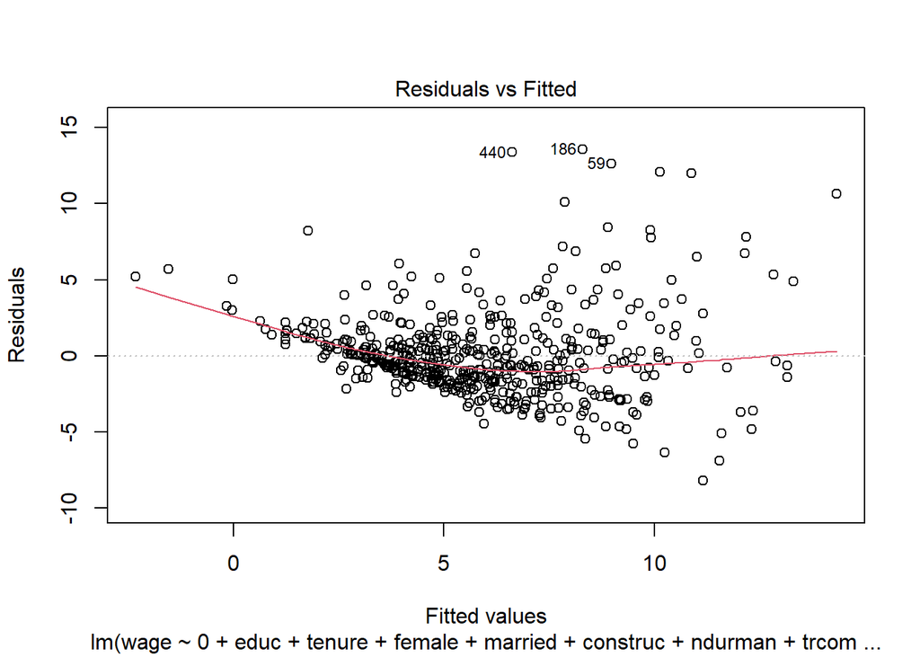

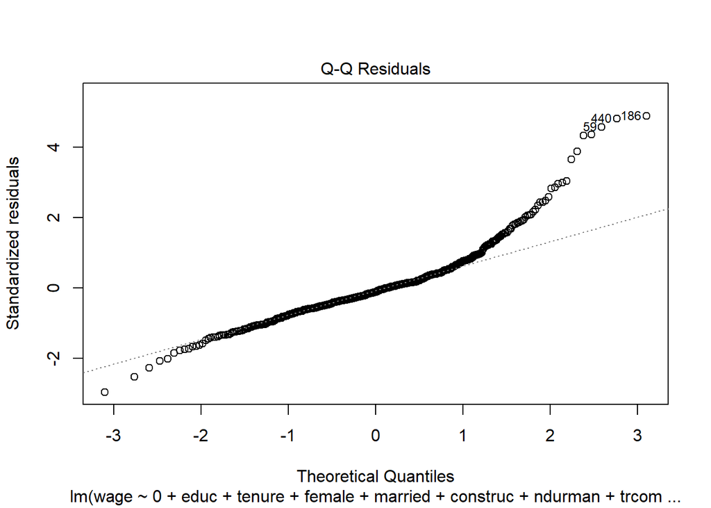

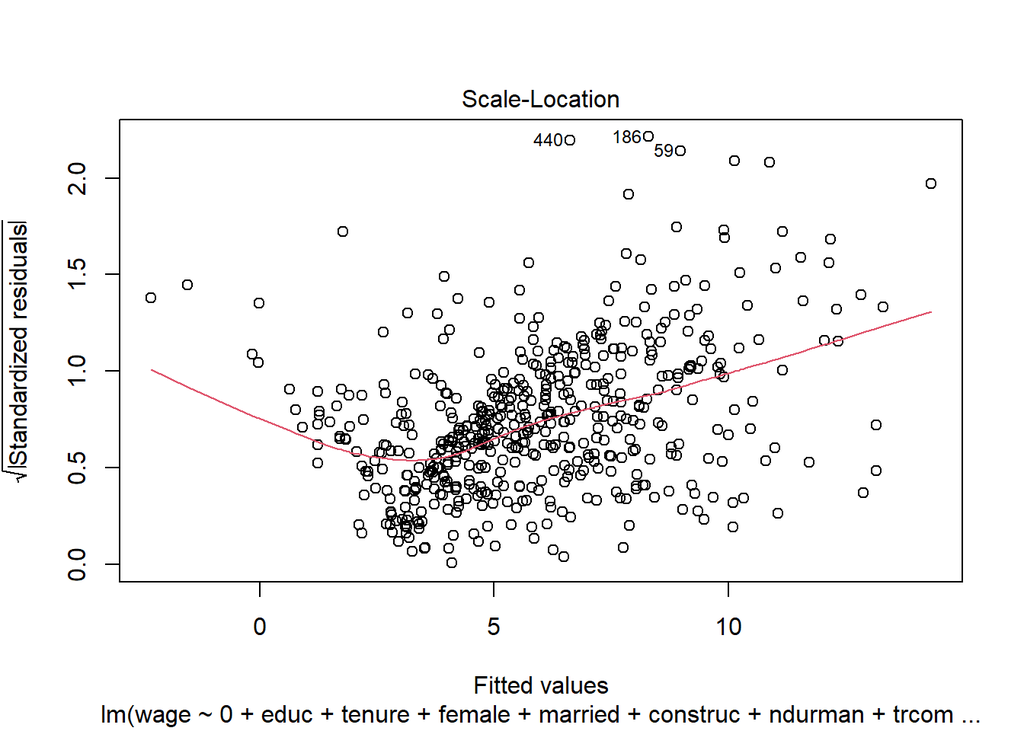

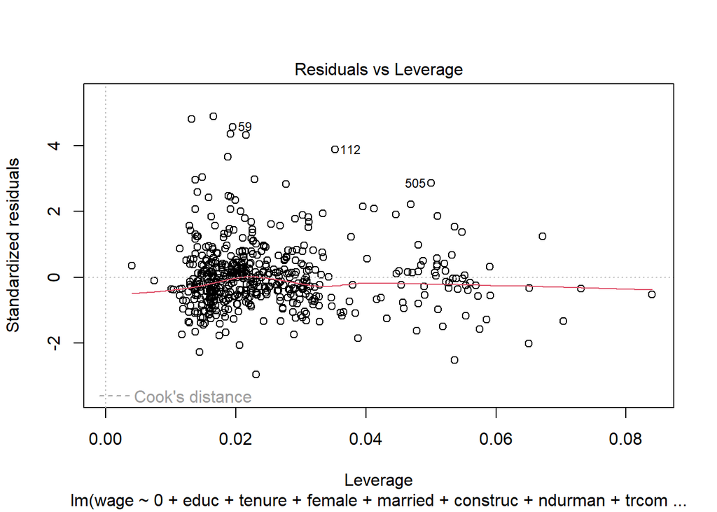

```r
plot(regexp)
```

Os residuos também não possuem uma boa cara. Mas podemos ver uma concetração na média zero e uma variancia constante, se retirarmos certos pontos discrepantes.

Agora vamos comparar os R quadrados de nossas duas regressôes:

```r
if (r2 > r3) {
  print ("Sem as profissões é melhor")
} else {
  print ("Com as profissões é melhor")
}
```

```
## [1] "Com as profissões é melhor"
```